# Cyclistic Documentation and Report

Zhen Hao

2022-09-21

# I: Ask phase

### Business Scenario / Problem Statement

Cyclistic is a bike-share program based in Chicago, there are two types of users, casual riders which pay based on single-ride or full-day passes, and annual members which pay annual fees. The finance analysts had concluded that annual members are much more profitable than casual riders, hence Moreno (Director of Marketing) would like to maximize number of annual members for growth. Hence, understanding the behaviour insights of casual and annual members allow us to create membership conversion campaign through data-driven insights.

This report is aimed to analyse difference of annual members and casual riders from database and create actionable insights to be used in the upcoming conversion campaign from casual riders to members.

### Sumarised into a question (Key Question)

*“How do annual members and casual riders use Cyclistic bikes differently?”*

### Our key stakeholders

1. Cyclistic executive team – They will approve the recommended marketing program
2. Lily Moreno (Director of marketing) – Need the insights to develop the campaigns
3. Customers – The insights, campaign, execution should always be dedicated to customers’ best interests.

# II: Preparing phase:

## Data Sources

#### Online Sources

https://divvy-tripdata.s3.amazonaws.com/index.html

#### Data Location

Downloaded and stored locally.

#### Type of data

Second Party data collected by Motivate International Inc.

#### Data organisation

The data is stored in CSV files and it was in monthly basis per file. For this analysis, most recent 12 month (September 2021 – August 2022) of data will be used for data credibility. Within the CSV files, there are 13 columns – • ride_id • rideable_type • started_at • ended_at • start_station_name • start_station_id • end_station_name • end_station_id • start_lat • start_lng • end_lat • end_lng • member_casual

#### Is the data ROCCC? (Data Credibility Assessment)

Reliable: Didn’t state how it was collected and consist of missing values, but based on the sample size, and collected by Divvy bicycle sharing service (same industry), it would be medium level for reliable.

Original: Collected by Motive International that is being used in Divvy bicycle, hence it was second hand data and its usable.

Comprehensive: Contains quite a lot of missing values but was able to remove the missing ones as there is sufficient data to be used for analysis after the removal. Current: Most current 12 months of data (captured on 16/9/2022).

Cited: It was made available by City of Chicago.

#### Lisencing and Privarcy

The license of the data is made available by Bikeshare LLC and City of Chicago (For more details, read [here](https://ride.divvybikes.com/data-license-agreement)).

All identifying personal information has been removed in this data for anonymous.

# III: Process phase

### Documentation of data wrangling/ cleaning

#### Loading library

```r
library(scales)
library(tidyverse)
library(skimr)
library(lubridate)
library(ggplot2)
```

#### Combining the seperated 12 months file into 1 file

```r
combined_trips <- dir("Cyclistic_Data_Frame",full.names = T) %>%  map_df(read_csv)
```

#### Removing empty values within the combined_trips

```r
combined_trips_v2 <- combined_trips %>% drop_na()
```

```r
skim_without_charts(combined_trips_v2)
```

Data summary

| Name | combined_trips_v2 |
| --- | --- |
| Number of rows | 4736517 |
| Number of columns | 13 |
| _______________________ |  |
| Column type frequency: |  |
| character | 7 |
| numeric | 4 |
| POSIXct | 2 |
| ________________________ |  |
| Group variables | None |

**Variable type: character**

| skim_variable | n_missing | complete_rate | min | max | empty | n_unique | whitespace |
| --- | --- | --- | --- | --- | --- | --- | --- |
| ride_id | 0 | 1 | 16 | 16 | 0 | 4560146 | 0 |
| rideable_type | 0 | 1 | 11 | 13 | 0 | 3 | 0 |
| start_station_name | 0 | 1 | 7 | 64 | 0 | 1365 | 0 |
| start_station_id | 0 | 1 | 3 | 44 | 0 | 1220 | 0 |
| end_station_name | 0 | 1 | 10 | 64 | 0 | 1395 | 0 |
| end_station_id | 0 | 1 | 3 | 44 | 0 | 1237 | 0 |
| member_casual | 0 | 1 | 6 | 6 | 0 | 2 | 0 |

**Variable type: numeric**

| skim_variable | n_missing | complete_rate | mean | sd | p0 | p25 | p50 | p75 | p100 |
| --- | --- | --- | --- | --- | --- | --- | --- | --- | --- |
| start_lat | 0 | 1 | 41.90 | 0.04 | 41.65 | 41.88 | 41.90 | 41.93 | 45.64 |
| start_lng | 0 | 1 | -87.64 | 0.03 | -87.83 | -87.66 | -87.64 | -87.63 | -73.80 |
| end_lat | 0 | 1 | 41.90 | 0.04 | 41.65 | 41.88 | 41.90 | 41.93 | 42.17 |
| end_lng | 0 | 1 | -87.64 | 0.02 | -87.83 | -87.66 | -87.64 | -87.63 | -87.53 |

**Variable type: POSIXct**

| skim_variable | n_missing | complete_rate | min | max | median | n_unique |
| --- | --- | --- | --- | --- | --- | --- |
| started_at | 0 | 1 | 2021-09-01 00:00:06 | 2022-08-31 23:58:50 | 2022-05-01 11:22:37 | 3928526 |
| ended_at | 0 | 1 | 2021-09-01 00:03:37 | 2022-09-01 19:10:49 | 2022-05-01 11:42:49 | 3936213 |

## Data Manipulation

```r
combined_trips_v2 <- combined_trips_v2 %>% rename(membership_type = member_casual)
```

### Adding ride_length =(ended_at - started_at ) in HMS format for analysis.

```r
combined_trips_v3 <- combined_trips_v2 %>%  mutate(ride_length = seconds_to_period(ended_at - started_at))
is.numeric(combined_trips_v3$ride_length) ## check if is in numeric for analysis.
```

```
## [1] TRUE
```

```r
rm(combined_trips,combined_trips_v2) #Remove files to clean up the clutter
```

#### Find the weekday where the bike ride begins and create a new column

```r
combined_trips_v3 <- combined_trips_v3 %>%  mutate(day_of_week = wday(started_at, label=TRUE))
str(combined_trips_v3$day_of_week) #Checking the order (Sunday......Saturday)
```

```
##  Ord.factor w/ 7 levels "Sun"<"Mon"<"Tue"<..: 1 1 7 3 2 3 7 3 2 7 ...
```

#### Data inspecting

```r
summary(combined_trips_v3)
```

```
##    ride_id          rideable_type        started_at
##  Length:4736517     Length:4736517     Min.   :2021-09-01 00:00:06.00
##  Class :character   Class :character   1st Qu.:2021-11-08 09:11:01.00
##  Mode  :character   Mode  :character   Median :2022-05-01 11:22:37.00
##                                        Mean   :2022-03-18 22:53:20.31
##                                        3rd Qu.:2022-07-03 20:05:28.00
##                                        Max.   :2022-08-31 23:58:50.00
##
##     ended_at                      start_station_name start_station_id
##  Min.   :2021-09-01 00:03:37.00   Length:4736517     Length:4736517
##  1st Qu.:2021-11-08 09:23:20.00   Class :character   Class :character
##  Median :2022-05-01 11:42:49.00   Mode  :character   Mode  :character
##  Mean   :2022-03-18 23:11:11.82
##  3rd Qu.:2022-07-03 20:29:52.00
##  Max.   :2022-09-01 19:10:49.00
##
##  end_station_name   end_station_id       start_lat       start_lng
##  Length:4736517     Length:4736517     Min.   :41.65   Min.   :-87.83
##  Class :character   Class :character   1st Qu.:41.88   1st Qu.:-87.66
##  Mode  :character   Mode  :character   Median :41.90   Median :-87.64
##                                        Mean   :41.90   Mean   :-87.64
##                                        3rd Qu.:41.93   3rd Qu.:-87.63
##                                        Max.   :45.64   Max.   :-73.80
##
##     end_lat         end_lng       membership_type
##  Min.   :41.65   Min.   :-87.83   Length:4736517
##  1st Qu.:41.88   1st Qu.:-87.66   Class :character
##  Median :41.90   Median :-87.64   Mode  :character
##  Mean   :41.90   Mean   :-87.64
##  3rd Qu.:41.93   3rd Qu.:-87.63
##  Max.   :42.17   Max.   :-87.53
##
##   ride_length                    day_of_week
##  Min.   :-2H -9M -5S             Sun:674463
##  1st Qu.:6M 14S                  Mon:619601
##  Median :10M 54S                 Tue:653147
##  Mean   :17M 51.5108458388315S   Wed:683704
##  3rd Qu.:19M 33S                 Thu:678137
##  Max.   :28d 6H 25M 1S           Fri:653455
##                                  Sat:774010
```

```r
skim_without_charts(combined_trips_v3)
```

Data summary

| Name | combined_trips_v3 |
| --- | --- |
| Number of rows | 4736517 |
| Number of columns | 15 |
| _______________________ |  |
| Column type frequency: |  |
| character | 7 |
| factor | 1 |
| numeric | 4 |
| POSIXct | 2 |
| Timespan | 1 |
| ________________________ |  |
| Group variables | None |

**Variable type: character**

| skim_variable | n_missing | complete_rate | min | max | empty | n_unique | whitespace |
| --- | --- | --- | --- | --- | --- | --- | --- |
| ride_id | 0 | 1 | 16 | 16 | 0 | 4560146 | 0 |
| rideable_type | 0 | 1 | 11 | 13 | 0 | 3 | 0 |
| start_station_name | 0 | 1 | 7 | 64 | 0 | 1365 | 0 |
| start_station_id | 0 | 1 | 3 | 44 | 0 | 1220 | 0 |
| end_station_name | 0 | 1 | 10 | 64 | 0 | 1395 | 0 |
| end_station_id | 0 | 1 | 3 | 44 | 0 | 1237 | 0 |
| membership_type | 0 | 1 | 6 | 6 | 0 | 2 | 0 |

**Variable type: factor**

| skim_variable | n_missing | complete_rate | ordered | n_unique | top_counts |
| --- | --- | --- | --- | --- | --- |
| day_of_week | 0 | 1 | TRUE | 7 | Sat: 774010, Wed: 683704, Thu: 678137, Sun: 674463 |

**Variable type: numeric**

| skim_variable | n_missing | complete_rate | mean | sd | p0 | p25 | p50 | p75 | p100 |
| --- | --- | --- | --- | --- | --- | --- | --- | --- | --- |
| start_lat | 0 | 1 | 41.90 | 0.04 | 41.65 | 41.88 | 41.90 | 41.93 | 45.64 |
| start_lng | 0 | 1 | -87.64 | 0.03 | -87.83 | -87.66 | -87.64 | -87.63 | -73.80 |
| end_lat | 0 | 1 | 41.90 | 0.04 | 41.65 | 41.88 | 41.90 | 41.93 | 42.17 |
| end_lng | 0 | 1 | -87.64 | 0.02 | -87.83 | -87.66 | -87.64 | -87.63 | -87.53 |

**Variable type: POSIXct**

| skim_variable | n_missing | complete_rate | min | max | median | n_unique |
| --- | --- | --- | --- | --- | --- | --- |
| started_at | 0 | 1 | 2021-09-01 00:00:06 | 2022-08-31 23:58:50 | 2022-05-01 11:22:37 | 3928526 |
| ended_at | 0 | 1 | 2021-09-01 00:03:37 | 2022-09-01 19:10:49 | 2022-05-01 11:42:49 | 3936213 |

**Variable type: Timespan**

| skim_variable | n_missing | complete_rate | min | max | median | n_unique |
| --- | --- | --- | --- | --- | --- | --- |
| ride_length | 0 | 1 | -59 | 59 | 10M 54S | 104 |

Upon inspecting, there are negative values on ride length, hence will remove the entries with it as the start time and end time is not valid in the first place.

```r
combined_trips_v4 <- combined_trips_v3 %>% filter(ride_length >= 0)
#skim_without_charts(combined_trips_v4) ##Checking the data again
```

#### Adding date, month, day, year, day_of_week columns, for furthur anaylsis.

```r
combined_trips_v4$date <- as.Date(combined_trips_v4$started_at)
combined_trips_v4$hour <- format(as.POSIXct(combined_trips_v4$started_at), "%H")
combined_trips_v4$month <- format(as.Date(combined_trips_v4$date), "%m")
combined_trips_v4$day <- format(as.Date(combined_trips_v4$date), "%d")
combined_trips_v4$year <- format(as.Date(combined_trips_v4$date), "%Y")
```

#### Changing data structure to ease up analysis

```r
combined_trips_v4$ride_length <- as.numeric(combined_trips_v4$ride_length)
combined_trips_v4$membership_type <- as.factor(combined_trips_v4$membership_type)
is.numeric(combined_trips_v4$ride_length)
```

```
## [1] TRUE
```

```r
summary(combined_trips_v4$ride_length)
```

```
##    Min. 1st Qu.  Median    Mean 3rd Qu.    Max.
##       0     374     654    1072    1173 2442301
```

**Hence, for now, I had completed the prepare and process.**

# IV: Analyze phase

## Descriptive Analysis (mean,median,min,max, using summary function on ride length, group by membership type.

#### Comparing members vs annual users

```r
aggregate(combined_trips_v4$ride_length ~ combined_trips_v4$membership_type, FUN = mean)
```

```
##   combined_trips_v4$membership_type combined_trips_v4$ride_length
## 1                            casual                     1546.0100
## 2                            member                      747.2585
```

```r
aggregate(combined_trips_v4$ride_length ~ combined_trips_v4$membership_type, FUN = median)
```

```
##   combined_trips_v4$membership_type combined_trips_v4$ride_length
## 1                            casual                           876
## 2                            member                           543
```

```r
aggregate(combined_trips_v4$ride_length ~ combined_trips_v4$membership_type, FUN = max)
```

```
##   combined_trips_v4$membership_type combined_trips_v4$ride_length
## 1                            casual                       2442301
## 2                            member                         89575
```

```r
aggregate(combined_trips_v4$ride_length ~ combined_trips_v4$membership_type, FUN = min)
```

```
##   combined_trips_v4$membership_type combined_trips_v4$ride_length
## 1                            casual                             0
## 2                            member                             0
```

#### Above line could be summarized using group_by() and summarise function.

```r
combined_trips_v4 %>%
  group_by(membership_type) %>%
    summarise(mean(ride_length),
            median(ride_length),
            max(ride_length),
            min(ride_length))
```

```
## # A tibble: 2 × 5
##   membership_type `mean(ride_length)` `median(ride_length)` max(ride_l…¹ min(r…²
##   <fct>                         <dbl>                 <dbl>        <dbl>   <dbl>
## 1 casual                        1546.                   876      2442301       0
## 2 member                         747.                   543        89575       0
## # … with abbreviated variable names ¹`max(ride_length)`, ²`min(ride_length)`
```

### Aggregating Data for analysis

Insight from the table:

Upon inspecting, found out that even though member pay for its annual fee, the ride length is lower as compared to casual users.

```r
data.frame(table(combined_trips_v4$membership_type))
```

```
##     Var1    Freq
## 1 casual 1923025
## 2 member 2813393
```

```r
combined_trips_v4 %>%
  group_by(membership_type) %>%
  summarise(mean(ride_length))
```

```
## # A tibble: 2 × 2
##   membership_type `mean(ride_length)`
##   <fct>                         <dbl>
## 1 casual                        1546.
## 2 member                         747.
```

## After some descriptive analysis, now it’s time for data visualisation!

```r
options(scipen=5) #Adding a small edit to avoid scientific symbol for data viz
```

# V: Share

#### Viz 1: Day preference between casual and member

Insight for viz below:

Casual users mostly use the services on weekend, whereas annual members uses it on weekdays.

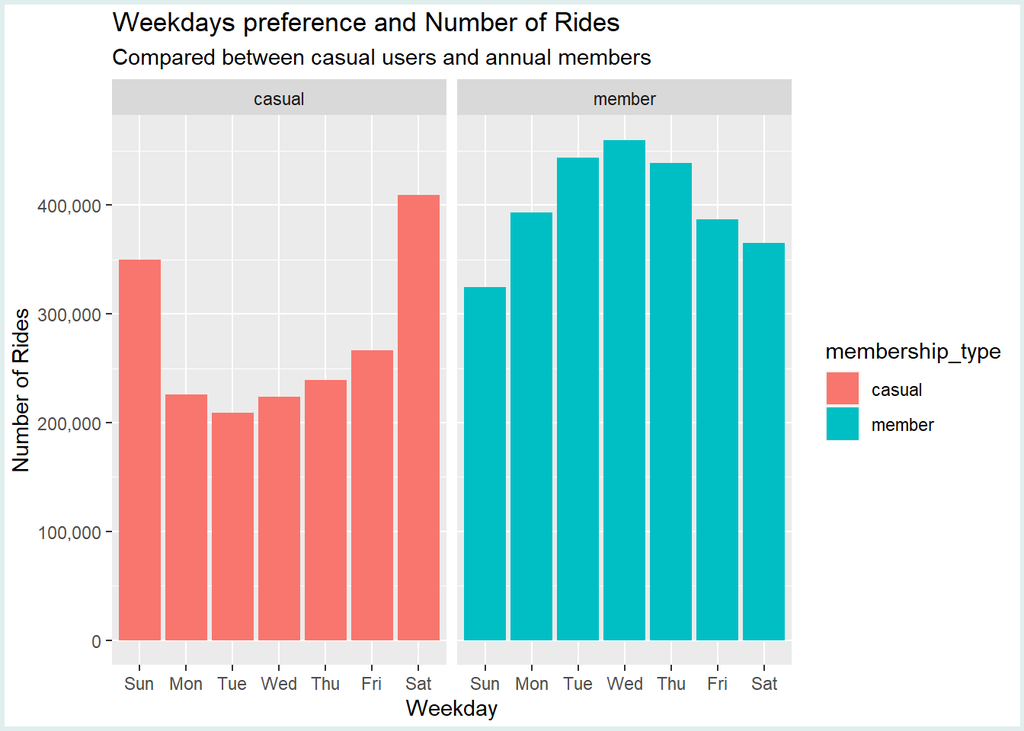

```r
combined_trips_v4 %>%
  group_by(membership_type,day_of_week) %>%
  summarise(number_of_rides = n(),
            average_duration = mean(ride_length)) %>%
  arrange(membership_type,day_of_week) %>%
  ggplot(aes(x=day_of_week, y=number_of_rides, fill = membership_type)) +
  geom_col(position = "dodge")+
  facet_wrap(vars(membership_type))+
  scale_y_continuous(labels=comma)+
  labs(title="Weekdays preference and Number of Rides",subtitle = "Compared between casual users and annual members", x= "Weekday", y="Number of Rides")+
  theme(plot.background = element_rect(color = "azure2", size = 2))
```

#### Viz 2: Average Casual vs member ride time per time

Insight for viz below:

Casual users mostly spent more duration when getting into a ride, they seems to enjoy riding leisurely as compared to having a destination.

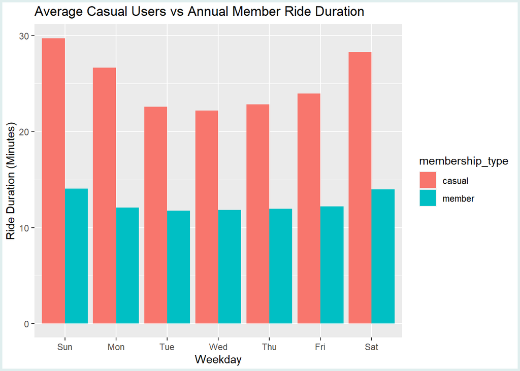

```r
combined_trips_v4 %>%
  group_by(membership_type,day_of_week) %>%
  summarise(number_of_rides = n(),
            average_duration=mean(ride_length)) %>%
  arrange(membership_type, day_of_week) %>%
  ggplot(aes(x=day_of_week, y=average_duration/60, fill= membership_type)) +
  geom_col(position = "dodge")+
  scale_y_continuous(labels=comma)+
  labs(title="Average Casual Users vs Annual Member Ride Duration", x= "Weekday", y="Ride Duration (Minutes)")+
  theme(plot.background = element_rect(color = "azure2", size = 2))
```

#### Viz 3: Preference of casual vs member on riding types

Insight for viz below:

Docked bike uses are unique to casual users (while having the lowest total usage) while classic bike is mostly used by member and casual (having highest usage between 2 groups) as well.

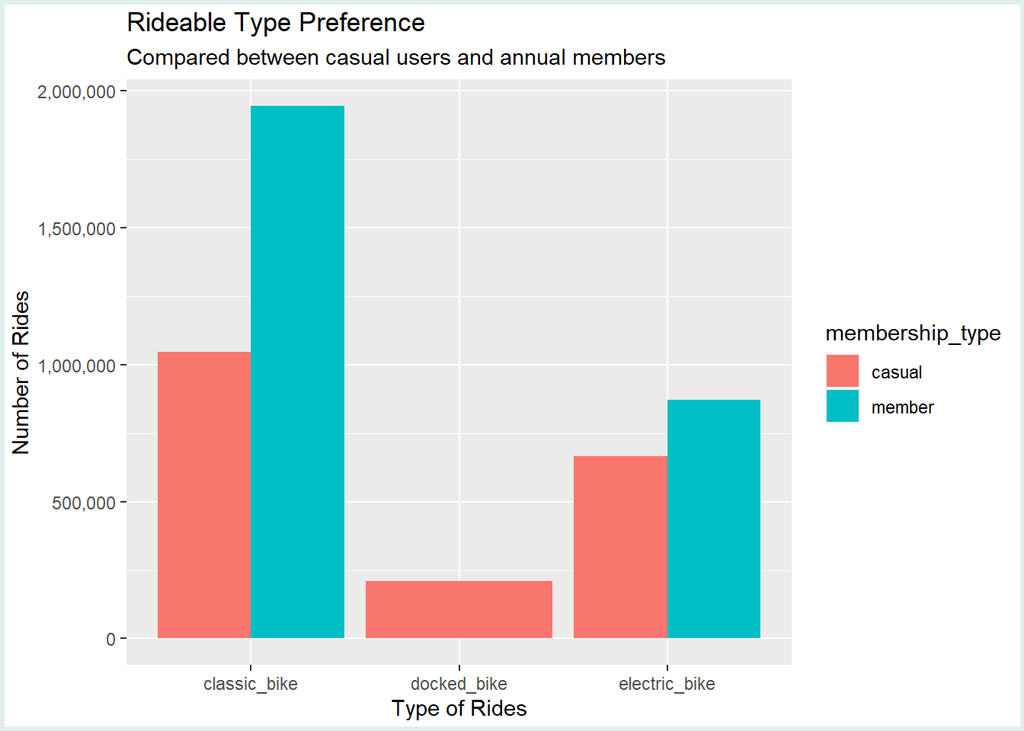

```r
combined_trips_v4 %>%
  group_by(membership_type,rideable_type) %>%
  summarise (number_of_rides = n()) %>%
  arrange(membership_type, rideable_type) %>%
  ggplot(aes(x=rideable_type, y=number_of_rides, fill = membership_type))+
  geom_col(position = "dodge")+
  scale_y_continuous(labels=comma)+
  labs(title="Rideable Type Preference",subtitle = "Compared between casual users and annual members", x= "Type of Rides", y="Number of Rides")+
  theme(plot.background = element_rect(color = "azure2", size = 2))
```

#### Viz 4: Monthly preference of casual vs member

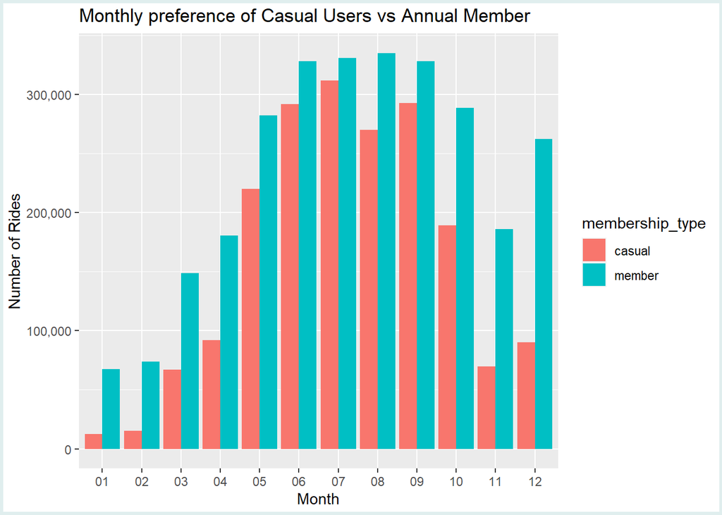

```r
combined_trips_v4 %>%
  group_by(membership_type, month) %>%
  summarise(number_of_rides = n(),
            average_duration=mean(ride_length)) %>%
  arrange(membership_type) %>%
  ggplot(aes(x=month, y=number_of_rides, fill= membership_type)) +
  geom_col(position = "dodge")+
  scale_y_continuous(labels=comma)+
  labs(title="Monthly preference of Casual Users vs Annual Member", x= "Month", y="Number of Rides")+
  theme(plot.background = element_rect(color = "azure2", size = 2))
```

#### Viz 5: Top 10 popular station

Insight for viz below:

The most popular station among casual users are “Streeter Dr & Grand Ave”, “DuSable Lake Shore Dr & Monroe St” and “Millennium Park”

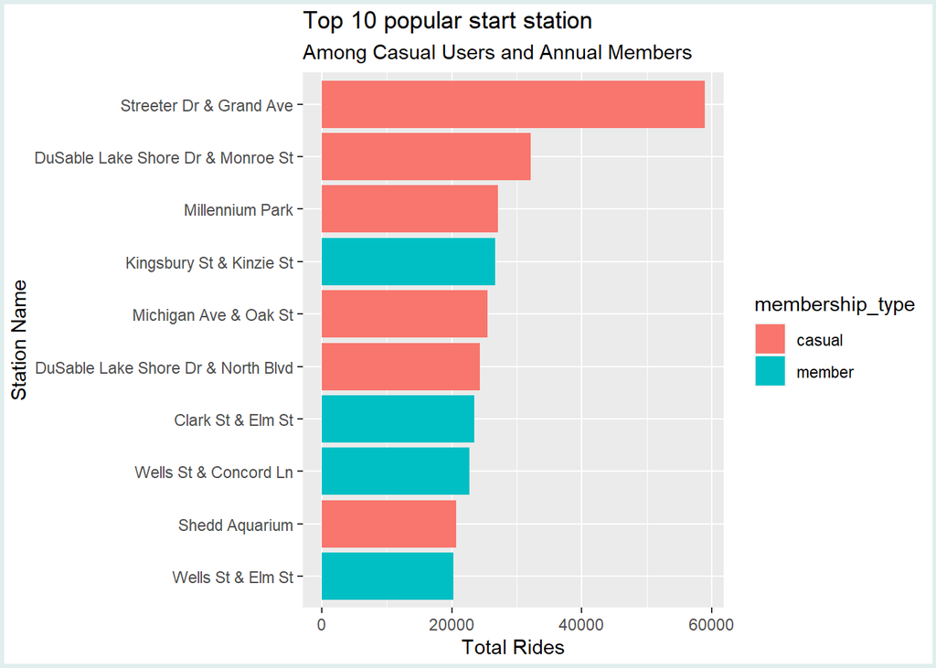

```r
top_station <- combined_trips_v4 %>%
  group_by(start_station_name, membership_type) %>%
  count(sort=TRUE, name= "Total Rides") %>%
  head(10)

top_station %>%
  ggplot(aes(reorder(start_station_name,`Total Rides`),
                           y=`Total Rides`,
                           fill=membership_type))+geom_col() +
  coord_flip()+
  labs(title="Top 10 popular start station", subtitle="Among Casual Users and Annual Members", x= "Station Name", y="Total Rides")+
  theme(plot.background = element_rect(color = "azure2", size = 2))
```

#### Viz 6: Hour preference between members and casual

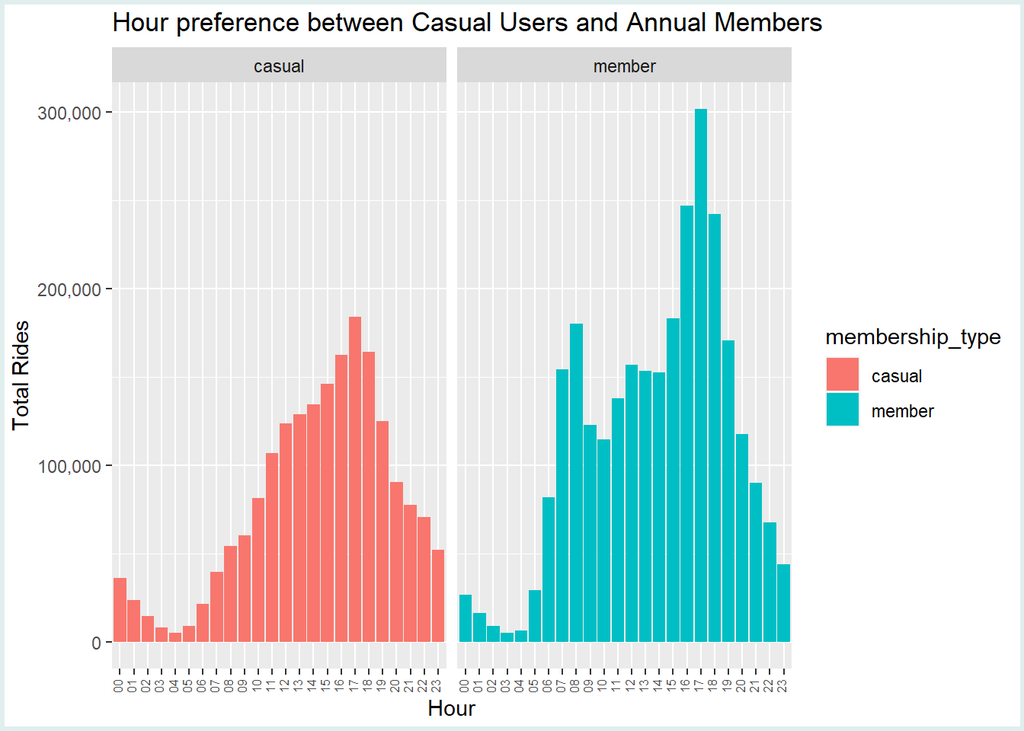

```r
combined_trips_v4 %>%
  group_by(membership_type, hour) %>%
  summarise(number_of_rides = n(),
            average_duration=mean(ride_length)) %>%
  arrange(membership_type) %>%
  ggplot(aes(x=hour, y=number_of_rides, fill= membership_type)) +
  geom_col(position = "dodge")+
  scale_y_continuous(labels=comma)+
  theme(axis.text.x = element_text(size = 06, angle=90, hjust=0.95,vjust=0.2))+
  facet_wrap(vars(membership_type))+
  labs(title="Hour preference between Casual Users and Annual Members",  x= "Hour", y="Total Rides")+
  theme(plot.background = element_rect(color = "azure2", size = 2))
```

# VI: Act

## Recommendation 1: Identifying potential casual users who are commuting to work using bike

Based on several graphs (look below), there a main distinction on the *usage* on casual users and annual members.

Based on the data analysis and visualization, it is evident that annual members use it for commuting to work as evident on these graphs:

1. Graph below shows the casual users used it during weekend (leisure purpose) and annual members used it during weekdays (commute to work)

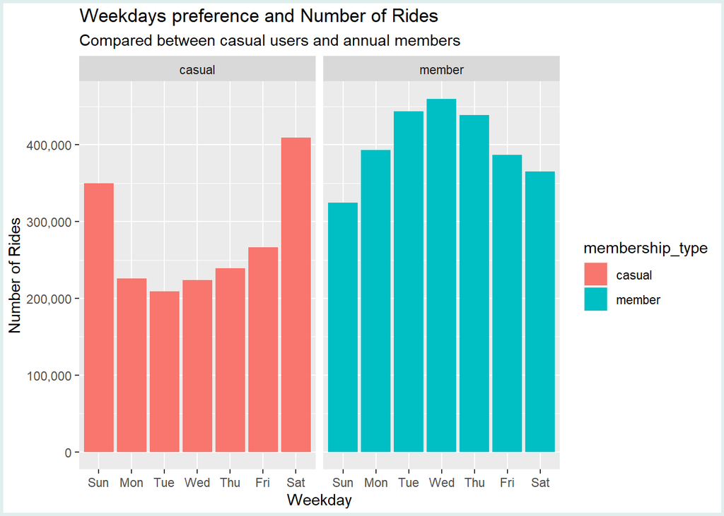

2. Graph below shows the annual members have lower ride duration as compared to casual users (which could due to annual members having direct destination from start station to nearby working end station)

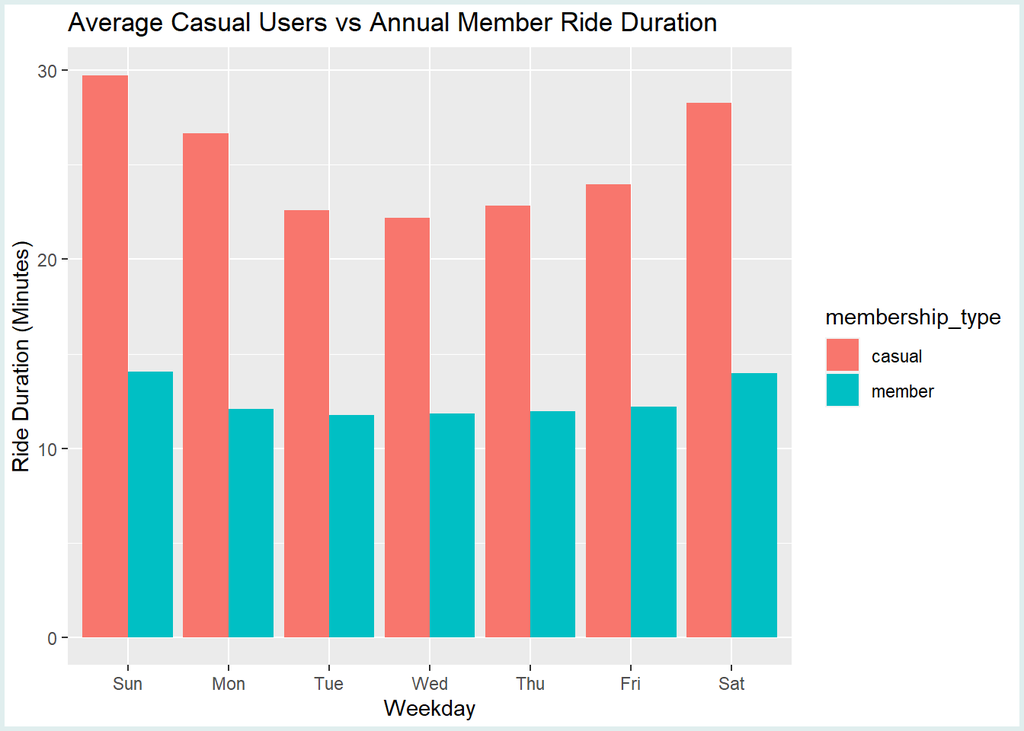

3. Graph below shows that the sudden surge on annual users matches the office operating hours (start and closing)

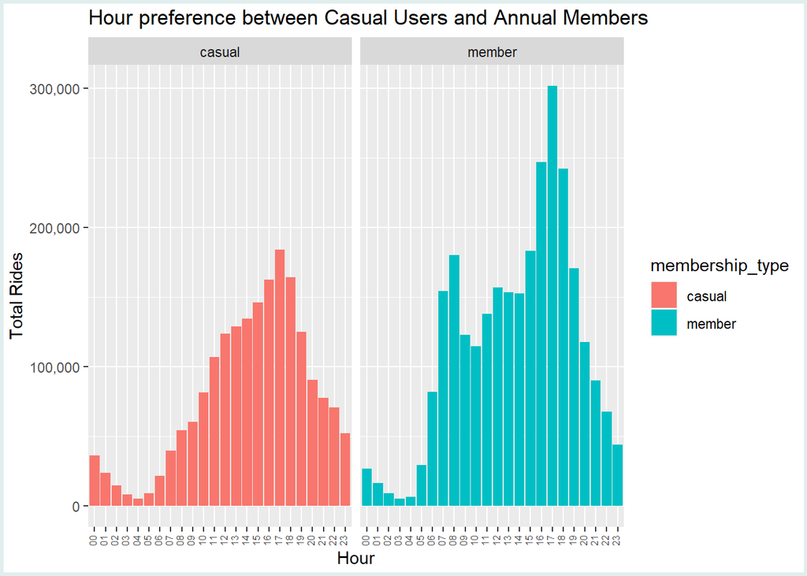

Based on all of these, marketing team could craft its message surrounding commuting to work to capture the potential casual users who prefer biking to work.

## Recommendation 2: Focus the campaign during Spring and Summer season

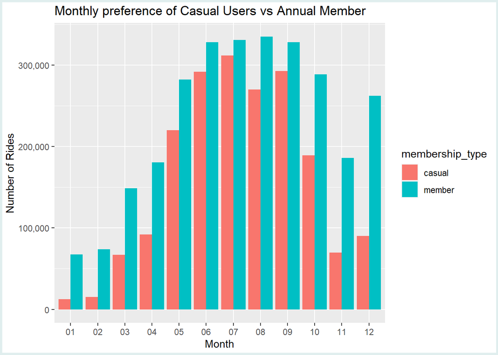

## Recommendation 3: Create marketing events around the top 3 stations.

As we identified the top stations for casual users, targeting the top 3 stations which is “Streeter Dr & Grand Ave”, “DuSable Lake Shore Dr & Monroe St” and “Millennium Park”, as creating an event is able to educate casual users on the perks of being an annual members directly which increases the chance of converting casual to annual members.

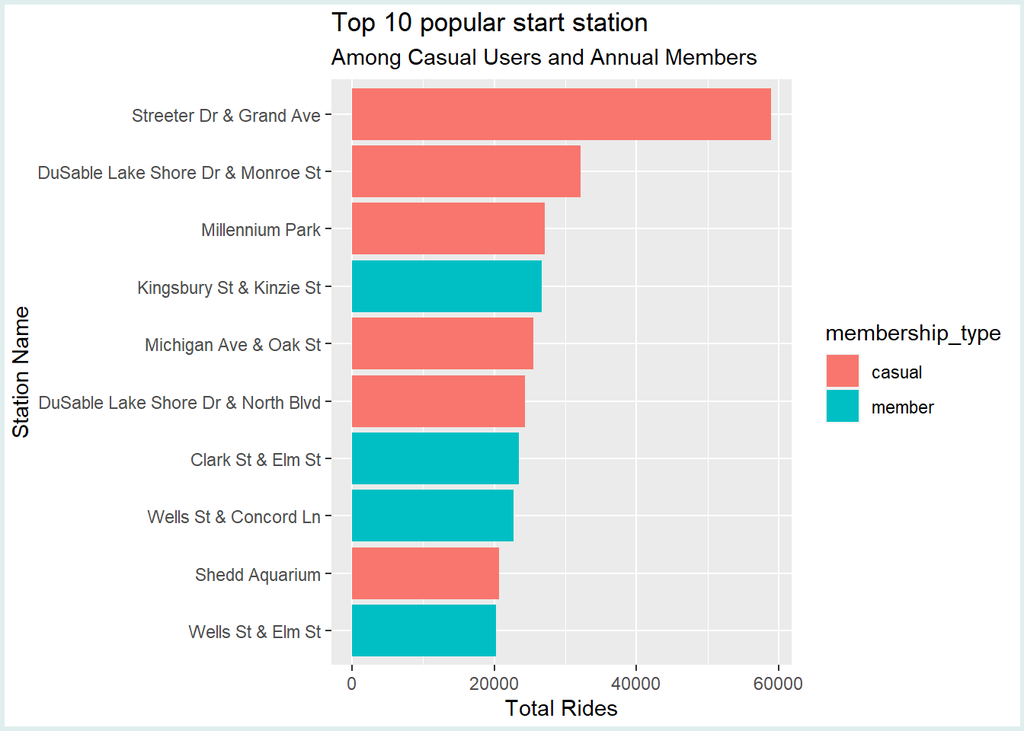